# Cleaning data

## assessing condions

```r
unique(data$condition)
```

```
## [1] 10    30    10|1  10|b  10I1  30|1  30|b  30f10 30I1
## Levels: 10 10|1 10|b 10I1 30 30|1 30|b 30f10 30I1
```

This is weird, am assuming that the “I” is in there accidentally, instead of “|”. Changing this requires reformatting to character again, changin the letter and then making it factor again.

```r
data$condition <- as.character(data$condition)
data$condition <- gsub("I", "|", data$condition, fixed = TRUE)
data$condition <- factor(data$condition)
```

ok, better, now check how many we have in each condition

```r
table(data$condition)
```

```
##
##    10  10|1  10|b    30  30|1  30|b 30f10
##   485   273    48   383   268    12   287
```

Who is missing?

```r
df <- data %>%
  mutate(unit_id = paste(researcher_name, study_species, individual_id, trial_day, sep = " | "))


keys_10    <- df %>% filter(condition == "10")    %>% distinct(unit_id, researcher_name, study_species)
keys_10_1  <- df %>% filter(condition == "10|1")  %>% distinct(unit_id)

missing_10_1 <- keys_10 %>%
  filter(!unit_id %in% keys_10_1$unit_id)
# great. issues with IDs when copying over!! in SZ data


keys_30     <- df %>% filter(condition == "30")    %>% distinct(unit_id, researcher_name, study_species)
keys_30_1   <- df %>% filter(condition == "30|1")  %>% distinct(unit_id)
keys_30f10  <- df %>% filter(condition == "30f10") %>% distinct(unit_id)

missing_30_1 <- keys_30 %>%
  filter(!unit_id %in% keys_30_1$unit_id)

missing_30f10 <- keys_30 %>%
  filter(!unit_id %in% keys_30f10$unit_id)



summary_missing <- full_join(
  missing_10_1  %>% count(researcher_name, study_species, name = "missing_10_1"),
  missing_30_1  %>% count(researcher_name, study_species, name = "missing_30_1"),
  by = c("researcher_name","study_species")
) %>%
  full_join(
    missing_30f10 %>% count(researcher_name, study_species, name = "missing_30f10"),
    by = c("researcher_name","study_species")
  ) %>%
  mutate(across(starts_with("missing_"), ~replace_na(.x, 0L))) %>%
  arrange(desc(missing_30f10 + missing_30_1 + missing_10_1))

summary_missing
```

```
## # A tibble: 5 × 5
##   researcher_name          study_species missing_10_1 missing_30_1 missing_30f10
##   <chr>                    <fct>                <int>        <int>         <int>
## 1 Prathik Amin/Joachim Fr… Neolamprolog…           40           40            40
## 2 Maria Cabrera Álvarez    Sparus aurata          100            0             0
## 3 Melissa Ramsay/Li Veiro… Gasterosteus…           24           27            19
## 4 Helen Spence-Jones/Cass… Gasterosteus…           12           12            12
## 5 Amelia Munson            Pungitius pu…            0            0            12
```

what do we have?

```r
counts_long <- as.data.frame(with(data, table(researcher_name, study_species, condition)))
counts_long <- subset(counts_long, Freq > 0)
counts_long <- counts_long[order(counts_long$researcher_name), ]
kable(counts_long)
```

|  | researcher_name | study_species | condition | Freq |
| --- | --- | --- | --- | --- |
| 36 | Amelia Munson | Pungitius pungitius | 10 | 48 |
| 85 | Amelia Munson | Pungitius pungitius | 10\|1 | 48 |
| 183 | Amelia Munson | Pungitius pungitius | 30 | 48 |
| 232 | Amelia Munson | Pungitius pungitius | 30\|1 | 48 |
| 330 | Amelia Munson | Pungitius pungitius | 30f10 | 36 |
| 9 | Helen Spence-Jones/Cassandra Scheibl | Gasterosteus aculeatus | 10 | 120 |
| 58 | Helen Spence-Jones/Cassandra Scheibl | Gasterosteus aculeatus | 10\|1 | 72 |
| 107 | Helen Spence-Jones/Cassandra Scheibl | Gasterosteus aculeatus | 10\|b | 48 |
| 156 | Helen Spence-Jones/Cassandra Scheibl | Gasterosteus aculeatus | 30 | 120 |
| 205 | Helen Spence-Jones/Cassandra Scheibl | Gasterosteus aculeatus | 30\|1 | 72 |
| 254 | Helen Spence-Jones/Cassandra Scheibl | Gasterosteus aculeatus | 30\|b | 12 |
| 303 | Helen Spence-Jones/Cassandra Scheibl | Gasterosteus aculeatus | 30f10 | 36 |
| 17 | Libor Závorka | Hucho hucho | 10 | 37 |
| 31 | Libor Závorka | Oncorhynchus mykiss | 10 | 48 |
| 66 | Libor Závorka | Hucho hucho | 10\|1 | 37 |
| 80 | Libor Závorka | Oncorhynchus mykiss | 10\|1 | 48 |
| 164 | Libor Závorka | Hucho hucho | 30 | 40 |
| 178 | Libor Závorka | Oncorhynchus mykiss | 30 | 45 |
| 213 | Libor Závorka | Hucho hucho | 30\|1 | 40 |
| 227 | Libor Závorka | Oncorhynchus mykiss | 30\|1 | 45 |
| 311 | Libor Závorka | Hucho hucho | 30f10 | 40 |
| 325 | Libor Závorka | Oncorhynchus mykiss | 30f10 | 45 |
| 46 | Maria Cabrera Álvarez | Sparus aurata | 10 | 100 |
| 340 | Maria Cabrera Álvarez | Sparus aurata | 30f10 | 59 |
| 12 | Melissa Ramsay/Li Veiros/Rebecca Gourlay | Gasterosteus aculeatus | 10 | 32 |
| 61 | Melissa Ramsay/Li Veiros/Rebecca Gourlay | Gasterosteus aculeatus | 10\|1 | 8 |
| 159 | Melissa Ramsay/Li Veiros/Rebecca Gourlay | Gasterosteus aculeatus | 30 | 30 |
| 208 | Melissa Ramsay/Li Veiros/Rebecca Gourlay | Gasterosteus aculeatus | 30\|1 | 3 |
| 306 | Melissa Ramsay/Li Veiros/Rebecca Gourlay | Gasterosteus aculeatus | 30f10 | 11 |
| 27 | Prathik Amin/Joachim Frommen | Neolamprologus pulcher | 10 | 40 |
| 174 | Prathik Amin/Joachim Frommen | Neolamprologus pulcher | 30 | 40 |
| 7 | Susanne Zajitschek | Danio rerio | 10 | 60 |
| 56 | Susanne Zajitschek | Danio rerio | 10\|1 | 60 |
| 154 | Susanne Zajitschek | Danio rerio | 30 | 60 |
| 203 | Susanne Zajitschek | Danio rerio | 30\|1 | 60 |
| 301 | Susanne Zajitschek | Danio rerio | 30f10 | 60 |

Quick recap: Joachim: no subsets prvided yet. Only 10 / 30

Maria: missing full 30, last mins for both 10 and 30 (but has provided 10 and first 10 for 30)

Melissa: Patchy data for the subsets

HELEN : recheck datasets!

```r
with(data, table(condition, trial_day))
```

```
##          trial_day
## condition   1   2   3   4
##     10    136 131 136  82
##     10|1   88  84  88  13
##     10|b   12  12  12  12
##     30    112 115 116  40
##     30|1   83  86  86  13
##     30|b    0   0   0  12
##     30f10  93  96  96   2
```

regardless…

let’s have a quick look at conditions (last min 10 vs 30)

## Last Minute

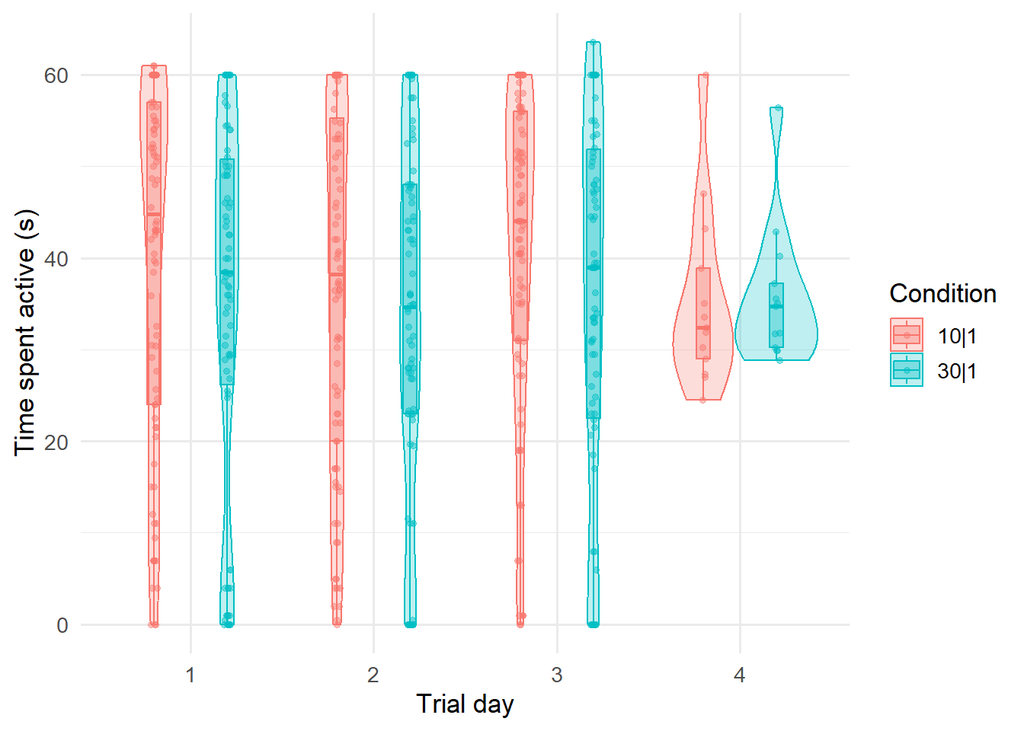

```r
sub_last <- subset(data, condition %in% c("10|1", "30|1"))

ggplot(sub_last, aes(x = trial_day, y = timespent_active, colour = condition, fill = condition)) +
  geom_violin(
    position = position_dodge(width = 0.8),
    alpha = 0.25,
    trim = TRUE
  ) +
  geom_boxplot(
    width = 0.15,
    outlier.shape = NA,
    position = position_dodge(width = 0.8),
    alpha = 0.35
  ) +
  geom_point(
    position = position_jitterdodge(jitter.width = 0.15, dodge.width = 0.8),
    alpha = 0.45,
    size = 1.2
  ) +
  labs(x = "Trial day", y = "Time spent active (s)", colour = "Condition", fill = "Condition") +
  theme_minimal(base_size = 13)
```

### split by species: LAST minute only

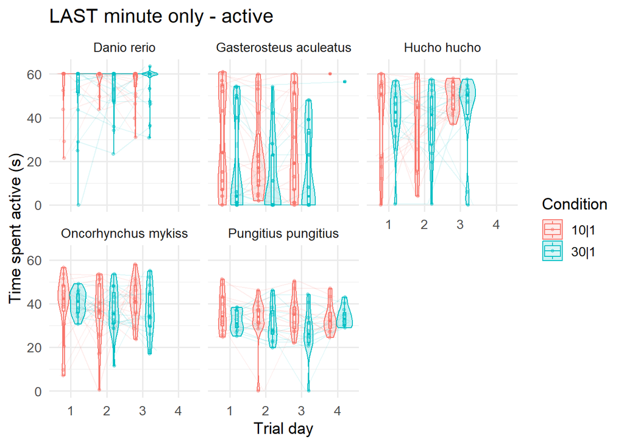

```r
ggplot(sub_last, aes(x = trial_day, y = timespent_active, colour = condition)) +
  geom_line(
    aes(group = interaction(individual_id, condition)),
    alpha = 0.12,
    position = position_dodge(width = 0.8)
  ) +
  geom_violin(
    aes(fill = condition),
    position = position_dodge(width = 0.8),
    alpha = 0.2,
    trim = TRUE
  ) +
  geom_boxplot(
    width = 0.15,
    outlier.shape = NA,
    position = position_dodge(width = 0.8),
    alpha = 0.3
  ) +
  geom_point(
    position = position_jitterdodge(jitter.width = 0.15, dodge.width = 0.8),
    alpha = 0.4,
    size = 1.1
  ) +
  facet_wrap(~study_species) +
  labs(x = "Trial day", y = "Time spent active (s)", colour = "Condition", fill = "Condition", title = "LAST minute only - active") +
  theme_minimal(base_size = 13)
```

fixed danio

## 10 mins

```
## `geom_line()`: Each group consists of only one observation.
## ℹ Do you need to adjust the group aesthetic?
```

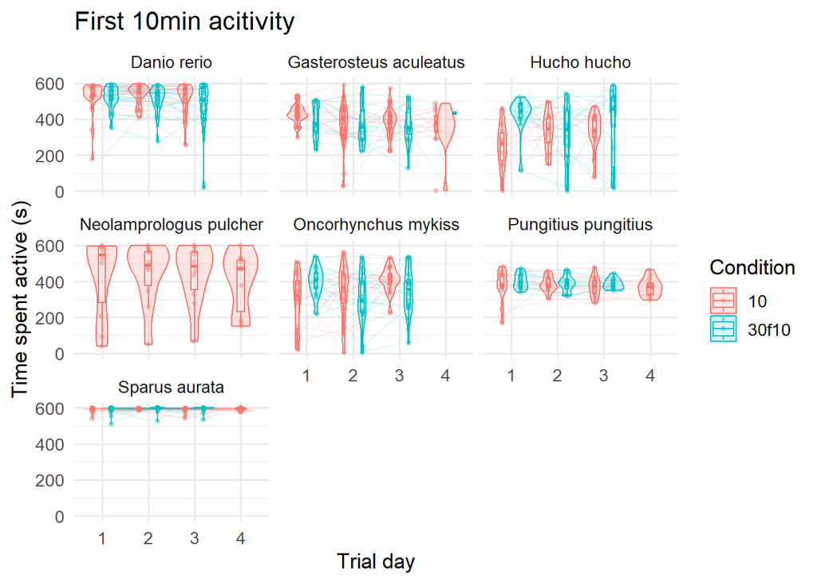

```r
sub10 <- subset(data, condition %in% c("10", "30f10"))

ggplot(sub10, aes(x = trial_day, y = timespent_active, colour = condition)) +
  geom_line(
    aes(group = interaction(individual_id, condition)),
    alpha = 0.12,
    position = position_dodge(width = 0.8)
  ) +
  geom_violin(
    aes(fill = condition),
    position = position_dodge(width = 0.8),
    alpha = 0.2,
    trim = TRUE
  ) +
  geom_boxplot(
    width = 0.15,
    outlier.shape = NA,
    position = position_dodge(width = 0.8),
    alpha = 0.3
  ) +
  geom_point(
    position = position_jitterdodge(jitter.width = 0.15, dodge.width = 0.8),
    alpha = 0.4,
    size = 1.1
  ) +
  facet_wrap(~study_species) +
  labs(x = "Trial day", y = "Time spent active (s)", colour = "Condition", fill = "Condition", title = "First 10min acitivity") +
  theme_minimal(base_size = 13)
```

Neolamprologus = Joachim, DATA NOT COMPLETE YET (i.e. only full 10 / full 30 min available)

### Different variables?

LATENCY

```
## `geom_line()`: Each group consists of only one observation.
## ℹ Do you need to adjust the group aesthetic?
```

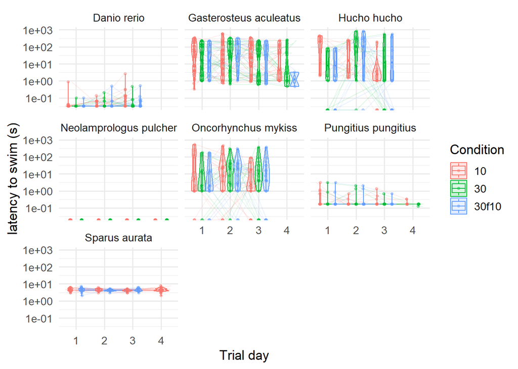

```r
sub_lat <- subset(data, condition %in% c("10", "30", "30f10"))

ggplot(sub_lat, aes(x = trial_day, y = latency_swim_freely, colour = condition)) +
  geom_line(
    aes(group = interaction(individual_id, condition)),
    alpha = 0.12,
    position = position_dodge(width = 0.8)
  ) +
  geom_violin(
    aes(fill = condition),
    position = position_dodge(width = 0.8),
    alpha = 0.2,
    trim = TRUE
  ) +
  geom_boxplot(
    width = 0.15,
    outlier.shape = NA,
    position = position_dodge(width = 0.8),
    alpha = 0.3
  ) +
  geom_point(
    position = position_jitterdodge(jitter.width = 0.15, dodge.width = 0.8),
    alpha = 0.4,
    size = 1.1
  ) +
  facet_wrap(~study_species) +
  labs(x = "Trial day", y = "latency to swim (s)", colour = "Condition", fill = "Condition") +

  theme_minimal(base_size = 13) +
  scale_y_log10()
```

CONTACT WITH SIDES or BOTTOM (called thigmotaxis here)

```
## `geom_line()`: Each group consists of only one observation.
## ℹ Do you need to adjust the group aesthetic?
```

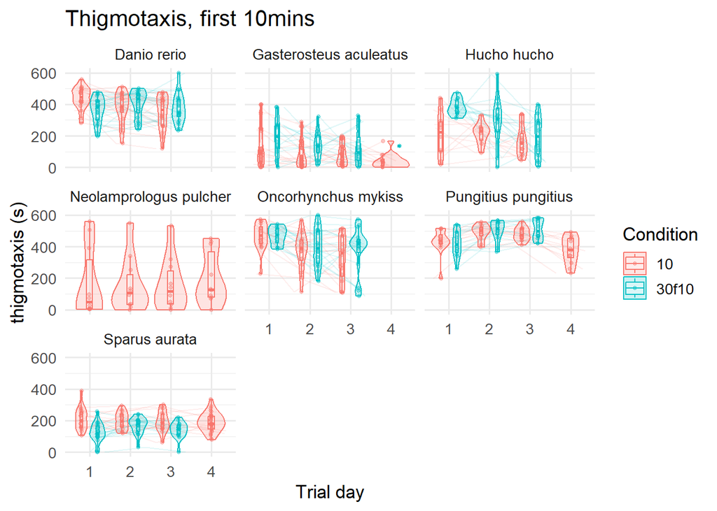

```r
ggplot(sub10, aes(x = trial_day, y =timespent_contact, colour = condition)) +
  geom_line(
    aes(group = interaction(individual_id, condition)),
    alpha = 0.12,
    position = position_dodge(width = 0.8)
  ) +
  geom_violin(
    aes(fill = condition),
    position = position_dodge(width = 0.8),
    alpha = 0.2,
    trim = TRUE
  ) +
  geom_boxplot(
    width = 0.15,
    outlier.shape = NA,
    position = position_dodge(width = 0.8),
    alpha = 0.3
  ) +
  geom_point(
    position = position_jitterdodge(jitter.width = 0.15, dodge.width = 0.8),
    alpha = 0.4,
    size = 1.1
  ) +
  facet_wrap(~study_species) +
  labs(x = "Trial day", y = "thigmotaxis (s)", colour = "Condition", fill = "Condition", title = "Thigmotaxis, first 10mins") +
  theme_minimal(base_size = 13)
```

Jo’s data not available yet. Possible to use overall and average per minute?

STARTLE

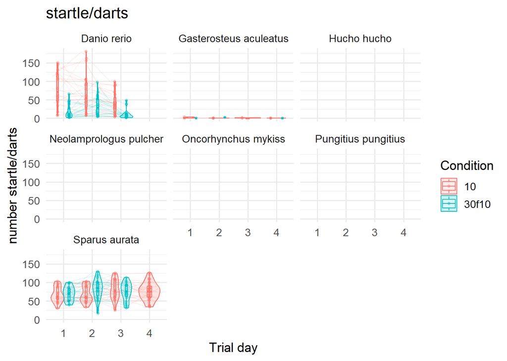

```r
ggplot(sub10, aes(x = trial_day, y =nb_dart_startle , colour = condition)) +
  geom_line(
    aes(group = interaction(individual_id, condition)),
    alpha = 0.12,
    position = position_dodge(width = 0.8)
  ) +
  geom_violin(
    aes(fill = condition),
    position = position_dodge(width = 0.8),
    alpha = 0.2,
    trim = TRUE
  ) +
  geom_boxplot(
    width = 0.15,
    outlier.shape = NA,
    position = position_dodge(width = 0.8),
    alpha = 0.3
  ) +
  geom_point(
    position = position_jitterdodge(jitter.width = 0.15, dodge.width = 0.8),
    alpha = 0.4,
    size = 1.1
  ) +
  facet_wrap(~study_species) +
  labs(x = "Trial day", y = "number startle/darts", colour = "Condition", fill = "Condition", title = "startle/darts") +
  theme_minimal(base_size = 13)
```

Not relevant for most species. Day 1 should be same for Danio - fish used in 30 min condition not bothered??? At least the 10min fish show decline over time, as would be expected.

## Novel Object Tests

### Latency approach

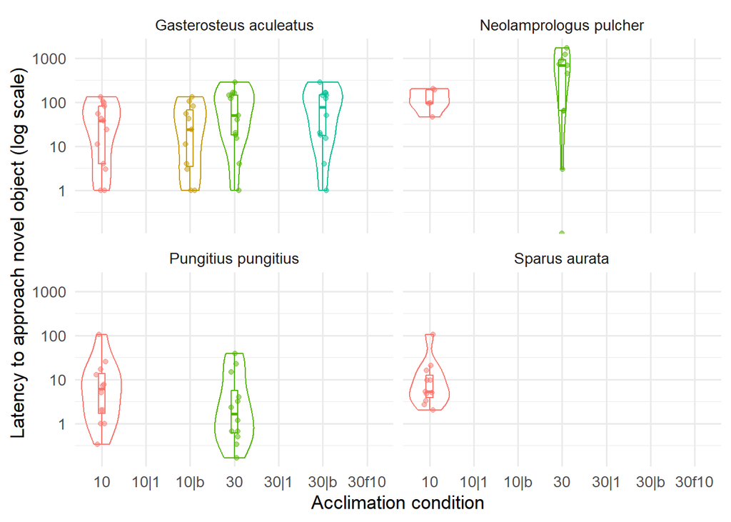

```r
novO_data <- data %>%
  dplyr::filter(trial_day == "4")


ggplot(novO_data, aes(x = condition, y = latency_approach_no, colour = condition)) +
  geom_violin(fill = NA, trim = TRUE) +
  geom_boxplot(width = 0.15, outlier.shape = NA) +
  geom_point(position = position_jitter(width = 0.12), alpha = 0.5) +
  scale_y_log10() +
  facet_wrap(~study_species) +
  labs(
    x = "Acclimation condition",
    y = "Latency to approach novel object (log scale)"
  ) +
  theme_minimal(base_size = 13) +
  theme(legend.position = "none")
```

Sparus/Maria: day 4 so far only available for 10min acclimation

### Latency touch

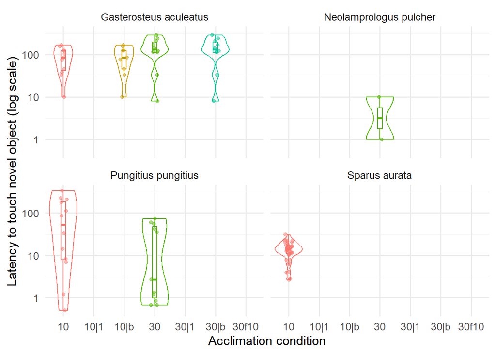

```r
ggplot(novO_data, aes(x = condition, y = latency_touch_no, colour = condition)) +
  geom_violin(fill = NA, trim = TRUE) +
  geom_boxplot(width = 0.15, outlier.shape = NA) +
  geom_point(position = position_jitter(width = 0.12), alpha = 0.5) +
  scale_y_log10() +
  facet_wrap(~study_species) +
  labs(
    x = "Acclimation condition",
    y = "Latency to touch novel object (log scale)"
  ) +
  theme_minimal(base_size = 13) +
  theme(legend.position = "none")
```

Neoplamprologus: NO touch in 10min condition, only 2 in 30

### Distance

Only use as covariate - that’s fish release distance from novel object, not behaviour

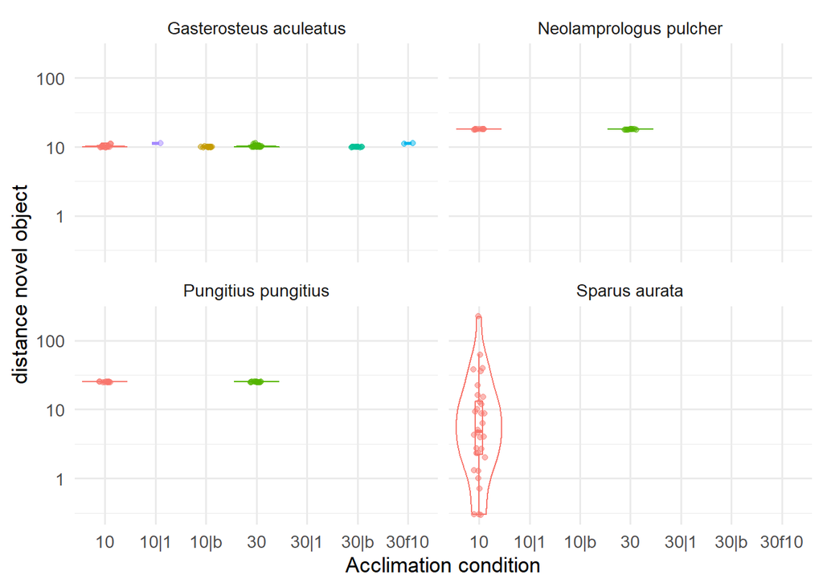

```r
ggplot(novO_data, aes(x = condition, y = distance_no, colour = condition)) +
  geom_violin(fill = NA, trim = TRUE) +
  geom_boxplot(width = 0.15, outlier.shape = NA) +
  geom_point(position = position_jitter(width = 0.12), alpha = 0.5) +
  scale_y_log10() +
  facet_wrap(~study_species) +
  labs(
    x = "Acclimation condition",
    y = "distance novel object"
  ) +
  theme_minimal(base_size = 13) +
  theme(legend.position = "none")
```